# Basic R and Basic Concepts

Ye Wang (yw1576@nyu.edu)

January 29, 2020

# About R

- R is an object-oriented programming language
  - Data
  - Procedures
- Object’s procedures can access and modify the data fields of objects.
- If you see a + means a parenthesis or bracket is open.
- R is case sensitive.
- Use / in path names. Not \.

# Using Third-party Code

- Relevant commands are: `install.packages` and `library`
- Find the appropriate packages and commands with Google and via searching in R:

  ```
  ?covariance
  ??covariance
  install.packages("sandwich")
  library(sandwich)
  library("sandwich")
  require(sanwich)
  sanwich::vcovHC
  ?vcovHC
  ```

# Install from other sources

- If you want to install packages on GitHub:

  ```
  require(devtools)
  install_github("wch/ggplot2")
  ```

- If you have a complied package downloaded on your computer (tar.gz):
- Tools -> Install Packages -> Find the location
- R cmd install *package name*

# Data types

- Character - strings
- Double / Numeric - numbers
- Logical - true/false
- Factor - unordered categorical variables

# Character

```r
my.name <- "Ye"
paste("My","name","is","Ye")
```

```
## [1] "My name is Ye"
```

```r
name.sentence <- paste0("My","name","is","Ye")
as.character(99)
```

```
## [1] "99"
```

```r
class(my.name)
```

```
## [1] "character"
```

# Numeric

```r
num <- 99.867
class(num)
```

```
## [1] "numeric"
```

```r
round(num, digits=2)
```

```
## [1] 99.87
```

```r
as.numeric("99") + 1
```

```
## [1] 100
```

```r
pi
```

```
## [1] 3.141593
```

```r
exp(1)
```

```
## [1] 2.718282
```

# Numeric

- `sin`, `exp`, `log`, `factorial`, `choose`, are some useful mathematical functions
- You probably noticed that “<-” is an assignment operator
- It lets you store objects and use them later on
- You can also use “=”
- To remove something, rm(object)
- To remove everything that is stored use rm(list=ls())

# Logical

- The logical type allows us to make statements about truth

```r
2 == 4
```

```
## [1] FALSE
```

```r
class(2==4)
```

```
## [1] "logical"
```

```r
my.name != num
```

```
## [1] TRUE
```

```r
"34" == 34
```

```
## [1] TRUE
```

- `==`, `!=`, `>`, `<`, `>=`, `<=`, `!`, `&`, `|`, `any`, `all`, etc

# Data Structures

- There are other ways to hold data, though:
  - Vectors/Lists
  - Matrices/Dataframes
  - Array

# Vectors

- Almost everything in R is a vector.

```r
as.vector(4)
```

```
## [1] 4
```

```r
4
```

```
## [1] 4
```

- We can combine elements in vectors with `c`, for concatenate:

```r
vec <- c("a","b","c")
vec
```

```
## [1] "a" "b" "c"
```

```r
c(2,3,vec)
```

```
## [1] "2" "3" "a" "b" "c"
```

# More Vectors

- We can index vectors in several ways

```r
vec[1]
```

```
## [1] "a"
```

```r
names(vec) <- c("first","second","third")
vec
```

```
##  first second  third
##    "a"    "b"    "c"
```

```r
vec["first"]
```

```
## first
##   "a"
```

# Creating Vectors

```r
vector1 <- 1:5
vector1
```

```
## [1] 1 2 3 4 5
```

```r
vector1 <- c(1:5,7,11)
vector1
```

```
## [1]  1  2  3  4  5  7 11
```

```r
vector2 <- seq(1, 7, 1)
vector2
```

```
## [1] 1 2 3 4 5 6 7
```

# Creating Vectors

```r
cbind(vector1,vector2)
```

```
##      vector1 vector2
## [1,]       1       1
## [2,]       2       2
## [3,]       3       3
## [4,]       4       4
## [5,]       5       5
## [6,]       7       6
## [7,]      11       7
```

```r
rbind(vector1,vector2)
```

```
##         [,1] [,2] [,3] [,4] [,5] [,6] [,7]
## vector1    1    2    3    4    5    7   11
## vector2    1    2    3    4    5    6    7
```

# Missingness

```r
vec[1] <- NA
vec
```

```
##  first second  third
##     NA    "b"    "c"
```

```r
is.na(vec)
```

```
##  first second  third
##   TRUE  FALSE  FALSE
```

```r
vec[!is.na(vec)] # vec[complete.cases(vec)]
```

```
## second  third
##    "b"    "c"
```

# Lists

- Lists are similar to vectors, but they allow for arbitrary mixing of types and lengths.

```r
listie <- list(first = vec, second = num)
listie
```

```
## $first
##  first second  third
##     NA    "b"    "c"
##
## $second
## [1] 99.867
```

# Lists

```r
listie[[1]]
```

```
##  first second  third
##     NA    "b"    "c"
```

```r
listie$first
```

```
##  first second  third
##     NA    "b"    "c"
```

# Basic Functions

```r
a <- c(1,2,3,4,5)
a
```

```
## [1] 1 2 3 4 5
```

```r
sum(a)
```

```
## [1] 15
```

```r
max(a)
```

```
## [1] 5
```

```r
min(a)
```

```
## [1] 1
```

# Basic Functions

```r
length(a)
```

```
## [1] 5
```

```r
length <- length(a)
b <- seq(from=0,to=5,by=.5)
c <- rep(10,27)
d <- runif(100)
```

```r
A <- matrix(c(1,2,3,4),nrow=2,ncol=2)
A
```

```
##      [,1] [,2]
## [1,]    1    3
## [2,]    2    4
```

```r
A[1,2]
```

```
## [1] 3
```

```r
A[1,]
```

```
## [1] 1 3
```

```r
A[1:2,]
```

```
##      [,1] [,2]
## [1,]    1    3
## [2,]    2    4
```

# Matrix Operations

- Its very easy to manipulate matrices:

```r
solve(A) #A^{-1}
```

```
##      [,1] [,2]
## [1,]   -2  1.5
## [2,]    1 -0.5
```

```r
10*A
```

```
##      [,1] [,2]
## [1,]   10   30
## [2,]   20   40
```

# Matrix Operations

```r
B<-diag(c(1,2)) #Extract or replace diagonal of a matrix
B
```

```
##      [,1] [,2]
## [1,]    1    0
## [2,]    0    2
```

```r
A%*%B
```

```
##      [,1] [,2]
## [1,]    1    6
## [2,]    2    8
```

# More Matrix Ops.

```r
t(A) # A'
```

```
##      [,1] [,2]
## [1,]    1    2
## [2,]    3    4
```

```r
rbind(A,B)
```

```
##      [,1] [,2]
## [1,]    1    3
## [2,]    2    4
## [3,]    1    0
## [4,]    0    2
```

# More Matrix Ops.

```r
cbind(A,B)
```

```
##      [,1] [,2] [,3] [,4]
## [1,]    1    3    1    0
## [2,]    2    4    0    2
```

```r
c(1,2,3)%x%c(1,1) # Kronecker Product
```

```
## [1] 1 1 2 2 3 3
```

- How to generate the OLS estimates with $X$ and $Y$?

# Naming Things

```r
rownames(A)
```

```r
rownames(A)<-c("a","b")
colnames(A)<-c("c","d")
A
```

```
##   c d
## a 1 3
## b 2 4
```

```r
A[,"d"]
```

```
## a b
## 3 4
```

# Arrary

- An arrary is similar to a matrix in many ways . . .

```r
array1 <- array(c(1,2,3,4,5,6,7,8), c(2,2,2))
array1
```

```
## , , 1
##
##      [,1] [,2]
## [1,]    1    3
## [2,]    2    4
##
## , , 2
##
##      [,1] [,2]
## [1,]    5    7
## [2,]    6    8
```

```r
array1[,2,]
```

```
##      [,1] [,2]
## [1,]    3    7
## [2,]    4    8
```

# Dataframes

- The workhorse
- Basically just a matrix that allows mixing of types.
- R has a bunch of datasets . . .

```r
# data() gives you all the datasets
data(iris)
head(iris)
```

```
##   Sepal.Length Sepal.Width Petal.Length Petal.Width Species
## 1          5.1         3.5          1.4         0.2  setosa
## 2          4.9         3.0          1.4         0.2  setosa
## 3          4.7         3.2          1.3         0.2  setosa
## 4          4.6         3.1          1.5         0.2  setosa
## 5          5.0         3.6          1.4         0.2  setosa
## 6          5.4         3.9          1.7         0.4  setosa
```

# Dataframes

- But you will generally work with your own datasets

```r
getwd()
```

```
## [1] "/Users/yewang/Dropbox/RECITATION_2020/1"
```

```r
setwd("/Users/yewang/Dropbox/RECITATION_2020/1")
```

- R can read any number of file types (.csv, .txt, etc.)

```r
#.CSV
dat.csv <- read.csv("http://stat511.cwick.co.nz/homeworks/acs_or.csv")
```

# Dataframes

```r
#STATA
require(foreign)
dat.data <- read.dta("https://stats.idre.ucla.edu/stat/data/test.dta")
```

# Dataframes

```r
# add variables
dat.data[, "intercept"] <- rep(1, nrow(dat.data))
# change the name of a variable
names(dat.data)[6] <- "constant"
# delete variables
dat.data <- dat.data[, -6]
# sort on one variable
dat.data <- dat.data[order(dat.data[, "mpg"]), ]
# remove all missing values
dat.data.complete <- dat.data[complete.cases(dat.data), ]
# select a subset
dat.data.subset <- dat.data[dat.data[, "make"] == "AMC", ]
dat.data.subset <- dat.data[1:3, ]
```

# Objects

- Many functions will return objects rather than a single datatype.

```r
X <- 1:100
Y <- rnorm(100,X)
out.lm <- lm(Y~X)
class(out.lm)
```

```
## [1] "lm"
```

```r
predict(out.lm)
```

[output not shown]

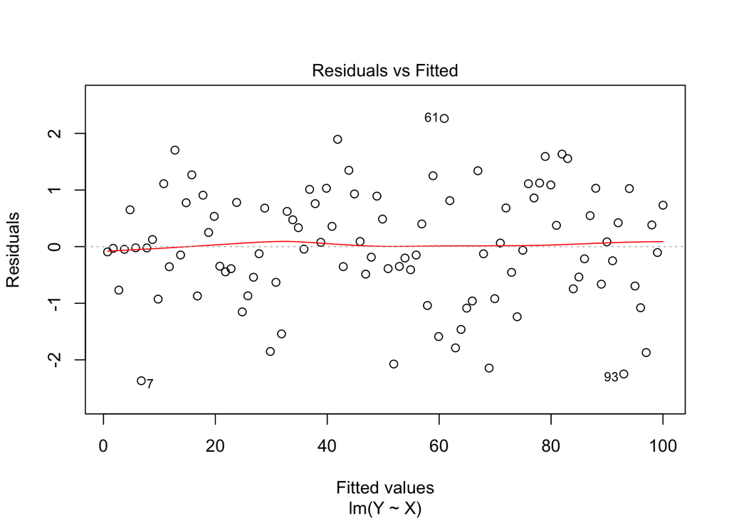

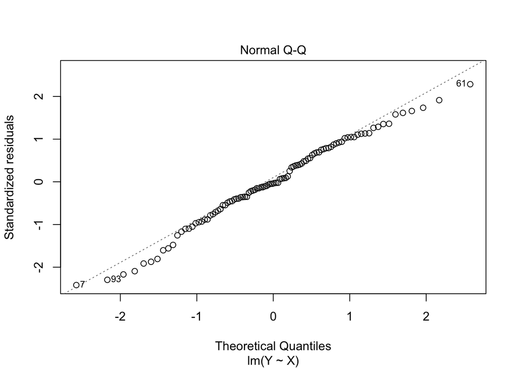

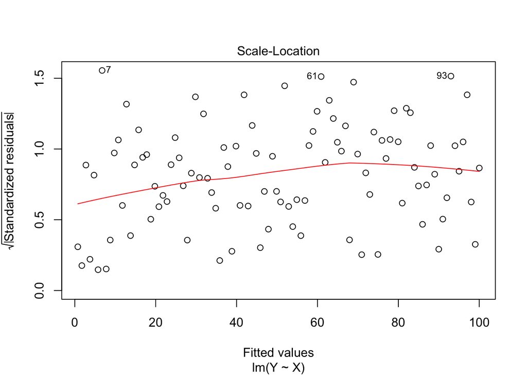

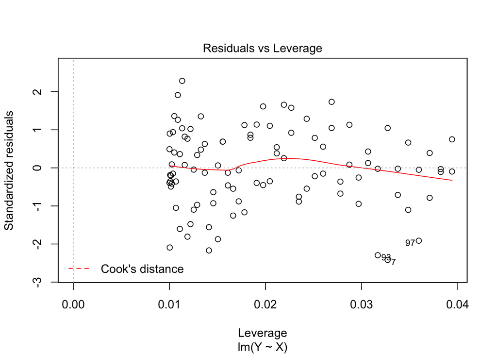

```r
plot(out.lm)
```

```r
summary(out.lm)
```

```
##
## Call:
## lm(formula = Y ~ X)
##
## Residuals:
##      Min       1Q   Median       3Q      Max
## -2.36921 -0.56311 -0.03733  0.76301  2.26425
##
## Coefficients:
##              Estimate Std. Error t value Pr(>|t|)
## (Intercept) -0.260806   0.200710  -1.299    0.197
## X            1.002744   0.003451 290.605   <2e-16 ***
## ---
## Signif. codes:  0 '***' 0.001 '**' 0.01 '*' 0.05 '.' 0.1 ' ' 1
##
## Residual standard error: 0.996 on 98 degrees of freedom
## Multiple R-squared:  0.9988, Adjusted R-squared:  0.9988
## F-statistic: 8.445e+04 on 1 and 98 DF,  p-value: < 2.2e-16
```

- Objects can have other data embedded inside them

```r
out.lm$coefficients
```

```
## (Intercept)           X
##  -0.2608062   1.0027442
```

# Control Flow

- loops
- if/else

# Loops

- for loops - a way to say “do this for each element of the index”
- “this” is defined in what follows the “for” expression

```r
for(i in 1:5) {
  cat(i*10," ")
}
```

```
## 10  20  30  40  50
```

```r
for(i in 1:length(vec)) {
  cat(vec[i]," ")
}
```

```
## NA  b  c
```

```r
for(i in vec) {
  cat(i," ")
}
```

```
## NA  b  c
```

# If/Else

```r
if(vec[2]=="b") print("Hello World!")
```

```
## [1] "Hello World!"
```

```r
if(vec[3]=="a") {
  print("Hello World!")
} else {
  print("!dlroW olleH")
}
```

```
## [1] "!dlroW olleH"
```

# Basic concepts

- When do we want ATT rather than ATE?
- What does conditional independence mean?
- What do we mean by “control?”
- When we have the population, does regression estimate still have uncertainty?
- Lesson One: Whenever you don’t understand something, simulate!

# A toy example

```r
N_pop <- 1000
X1 <- rnorm(N_pop, 3, 1)
Y0 <- abs(rnorm(N_pop, 5, 2)) #+ 1.5*X1 + 0.4*X1^2
Y1 <- Y0 + rnorm(N_pop, 3, 1)
TE <- Y1 - Y0
ATE <- mean(TE)
```

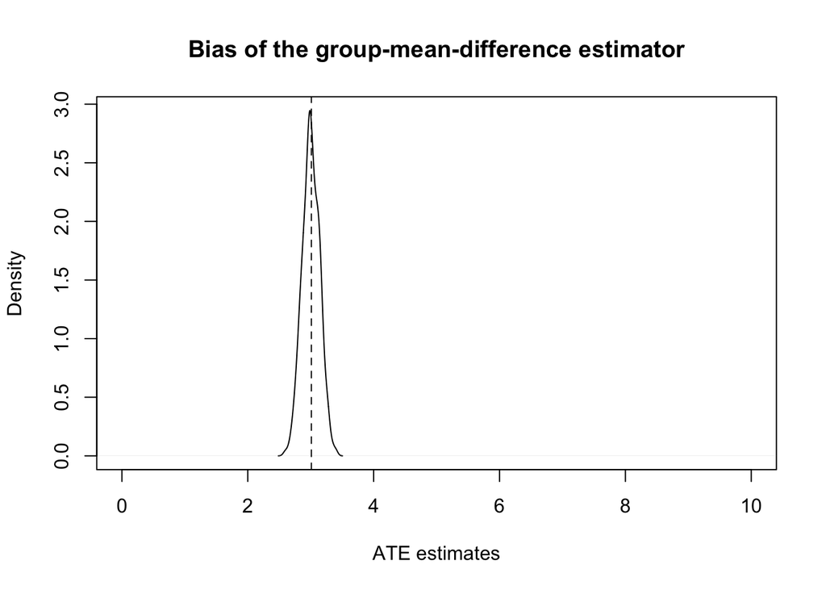

```r
nboots <- 1000
ATE_est <- ATT <- rep(NA, nboots)
for (i in 1:nboots){
  # pscore <- abs((X1 - min(X1))/(max(X1) - min(X1)))
  # D <- rbinom(N, 1, pscore)
  D <- rbinom(N_pop, 1, 0.3)
  # D <- rep(0, N_pop)
  # D[sample(N_pop, 500)] <- 1
  Y <- D*Y1 + (1-D)*Y0
  data.pop <- data.frame(Y=Y, D=D)
  ATT[i] <- mean(TE[D==1])
  ATE_est[i] <- mean(Y[D==1]) - mean(Y[D==0])
}
plot(density(ATE_est), main = "Bias of the group-mean-difference estimator", xlab = "ATE estimates", xlim = c(0, 10))
abline(v = ATE, lty = 2)
```

```r
cat("The true ATE is", ATE, ", and the average of ATE estimates is", mean(ATE_est), "\n")
```

```
## The true ATE is 3.009998 , and the average of ATE estimates is 3.002368
```

```r
cat("The sampling variance of ATE estimates is", var(ATE_est), "\n")
```

```
## The sampling variance of ATE estimates is 0.0190963
```

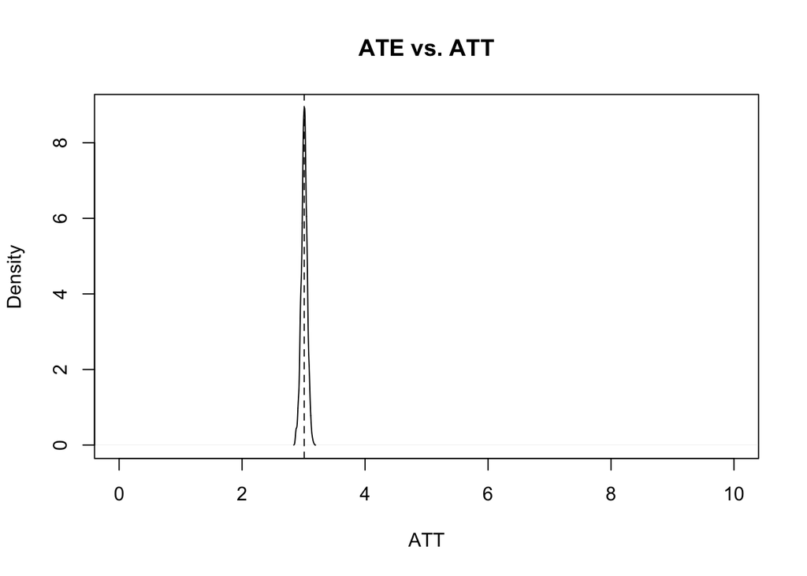

```r
plot(density(ATT), main = "ATE vs. ATT", xlab = "ATT", xlim = c(0, 10))
abline(v = ATE, lty = 2)
```

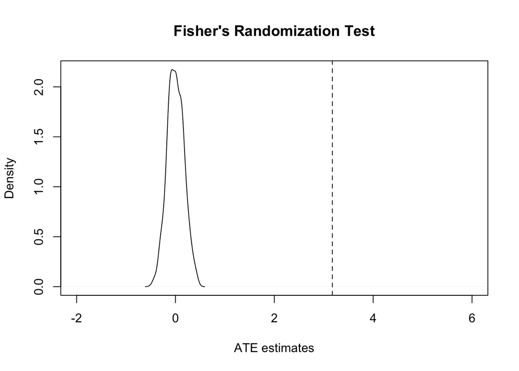

```r
nboots <- 1000
D <- rep(0, N_pop)
D[sample(N_pop, 500)] <- 1
Y <- D*Y1 + (1-D)*Y0
ATE_original <- mean(Y[D==1]) - mean(Y[D==0])

ATE_boot <- rep(NA, nboots)
for (i in 1:nboots){
  D_boot <- rep(0, N_pop)
  D_boot[sample(N_pop, 500)] <- 1
  ATE_boot[i] <- mean(Y[D_boot==1]) - mean(Y[D_boot==0])
}
plot(density(ATE_boot), main = "Fisher's Randomization Test", xlab = "ATE estimates", xlim = c(-2, 6))
abline(v = ATE_original, lty = 2)
```

```r
cat("The 95% confidence interval under the null distribution is", quantile(ATE_boot, c(0.025, 0.975)), "\n")
```

```
## The 95% confidence interval under the null distribution is -0.3208454 0.3467824
```

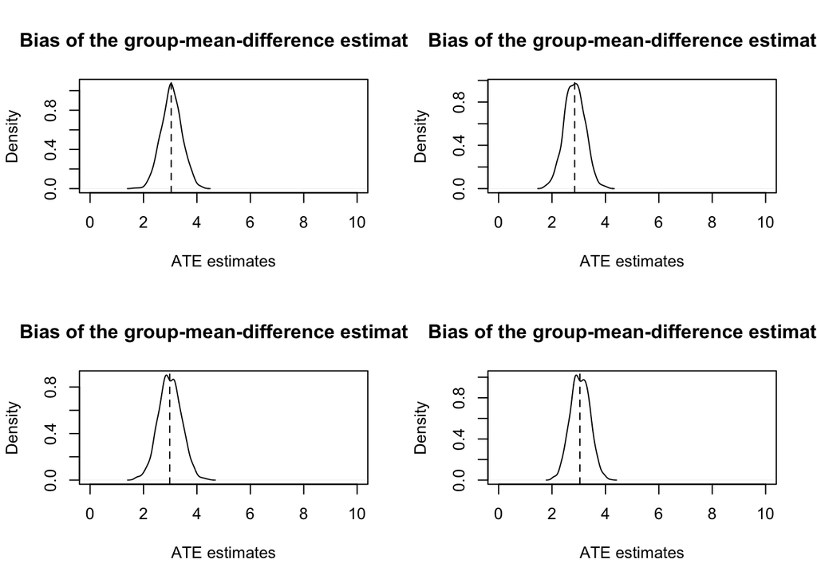

```
## The total variance of ATE estimates is 0.1588628
```

```
## The variance of ATE estimates due to design is 0.1517845
```

```
## The variance of ATE estimates due to sampling is 0.009587187
```

```
## The average variance estimates is 0.1590043
```

# Causal inference as a sampling problem

- In the classic sampling world, we want to estimate the population mean ($n$) via the average of a random sample ($N$).
- We use a dummy variable $S_i$ to denote whether $i$ is included in the sample.
  $$\hat{\bar Y} = \frac{1}{N} \sum_{i=1}^N Y_i = \frac{1}{N} \sum_{i=1}^n S_i Y_i$$
- When the sampling probability ($p_i = P(S_i = 1)$) varies across individuals, we need some adjustment when conducting the estimation:
  $$\hat{\bar Y} = \frac{1}{N} \sum_{i=1}^N \frac{Y_i}{p_i} = \frac{1}{n} \sum_{i=1}^n \frac{S_i Y_i}{p_i}$$
- This is the so-called Horvitz-Thompson estimator.
- For higher efficiency, we can also use the Hajek estimator:
  $$\hat{\bar Y} = \frac{\sum_{i=1}^N\frac{Y_i}{p_i}}{\sum_{i=1}^N\frac{1}{p_i}} = \frac{\sum_{i=1}^n \frac{S_i Y_i}{p_i}}{\sum_{i=1}^n \frac{S_i}{p_i}}$$
- In causal inference, we want to estimate two population means: $\bar Y(1)$ and $\bar Y(0)$.
- Assignment can be seen as a second sampling:
  $$\hat{\bar Y}(1) = \frac{1}{N_1} \sum_{i=1}^{N_1} Y_i = \frac{1}{N_1} \sum_{i=1}^N D_i Y_i$$
  $$\hat{\bar Y}(0) = \frac{1}{N_0} \sum_{i=1}^{N_0} Y_i = \frac{1}{N_0} \sum_{i=1}^N (1-D_i) Y_i$$
- We can also construct the Horvitz-Thompson estimator and Hajek estimator in causal inference:
  $$\widehat{ATE}_{HT} = \frac{1}{N} \sum_{i=1}^N \frac{D_i Y_i}{p_i} - \frac{1}{N} \sum_{i=1}^N \frac{(1-D_i) Y_i}{1-p_i}$$

$$\widehat{ATE}_{HA} = \frac{\sum_{i=1}^N \frac{D_i Y_i}{p_i}}{\sum_{i=1}^N \frac{D_i}{p_i}} - \frac{\sum_{i=1}^N \frac{(1-D_i) Y_i}{1-p_i}}{\sum_{i=1}^N \frac{1-D_i}{1-p_i}}$$

# A special case: Bernoulli trial with equal probability

- How to estimate the ATE in this case?
- Now the two estimators become:
  $$\widehat{ATE}_{HT} = \frac{1}{N} \sum_{i=1}^N \frac{D_i Y_i}{p} - \frac{1}{N} \sum_{i=1}^N \frac{(1-D_i) Y_i}{1-p} = \frac{1}{Np} \sum_{i=1}^N D_i Y_i - \frac{1}{N(1-p)} \sum_{i=1}^N (1-D_i) Y_i$$
  and
  $$\begin{aligned}
  \widehat{ATE}_{HA} = & \frac{\sum_{i=1}^N \frac{D_i Y_i}{p}}{\sum_{i=1}^N \frac{D_i}{p}} - \frac{\sum_{i=1}^N \frac{(1-D_i) Y_i}{1-p}}{\sum_{i=1}^N \frac{1-D_i}{1-p}} = \frac{1}{\sum_{i=1}^N D_i} \sum_{i=1}^N D_i Y_i - \frac{1}{\sum_{i=1}^N (1-D_i)} \sum_{i=1}^N (1-D_i) Y_i \\
  = & \frac{1}{N_1} \sum_{i=1}^N D_i Y_i - \frac{1}{N_0} \sum_{i=1}^N (1-D_i) Y_i
  \end{aligned}$$